# R Notebook

Correlation (total calcium by dietary calcium intake) Alt: There will be a positive correlation between total calcium and calcium intake. Null: There will be no correlation between total calcium and calcium intake.

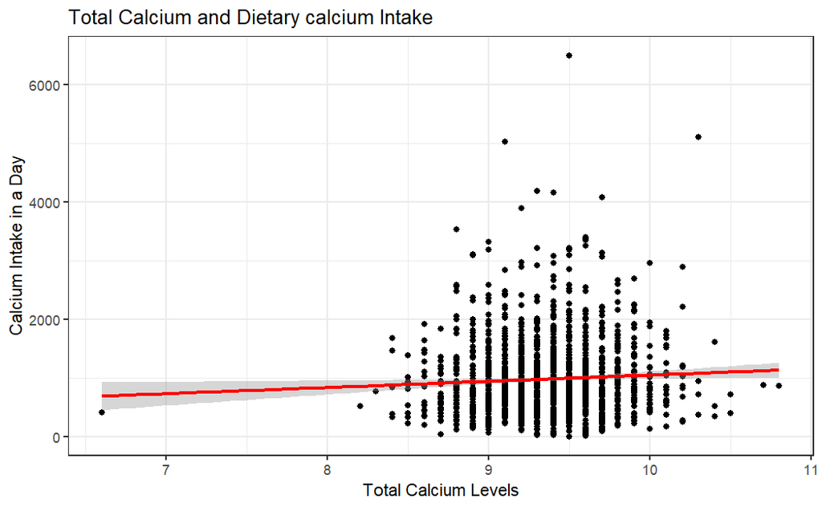

```r
#scatter plot code: #ggplot(aes(x=DepVar, y=IndVar), data=) + geom_point(color="") + geom_smooth(method=lm, color="") + labs(x="", y="") + theme_bw()

NHANES2017_2018%>% ggplot(.,aes(x=Total_Calcium, y=Diet_Calcium)) + geom_point(color="black") + geom_smooth(method=lm, color="red") + labs(x="Total Calcium Levels", y="Calcium Intake in a Day", title="Total Calcium and Dietary calcium Intake") + theme_bw()
```

```r
#correlation test code: cor.test(data$DepVar, data$IndVar, method="pearson")

cor.test(NHANES2017_2018$Total_Calcium, NHANES2017_2018$Diet_Calcium, method="pearson")
```

```
    Pearson's product-moment correlation

data:  NHANES2017_2018$Total_Calcium and NHANES2017_2018$Diet_Calcium
t = 2.4352, df = 1644, p-value = 0.01499
alternative hypothesis: true correlation is not equal to 0
95 percent confidence interval:
 0.01167046 0.10795595
sample estimates:
       cor
0.05995266
```

The Pearson correlation coefficient is 0.06. The correlation is significant with a p-value of 0.01. The statistics support the alt hypothesis with a slightly positive significant correlation between total calcium and dietary calcium intake.

Chi-squared Test & prop tables:

```r
#a. generate a frequency table by raw counts and percentages
TtlCalcCat_TMBDCat_table <- xtabs(~TtlCalcCat + TMBDCat, data=NHANES2017_2018)
TtlCalcCat_TMBDCat_table
```

```
               TMBDCat
TtlCalcCat      Healthy Osteopenia
  Hypercalcemic       2          0
  Hypocalcemic        4          5
  Normal            457       1178
```

```r
prop.table(TtlCalcCat_TMBDCat_table)*100
```

```
               TMBDCat
TtlCalcCat         Healthy Osteopenia
  Hypercalcemic  0.1215067  0.0000000
  Hypocalcemic   0.2430134  0.3037667
  Normal        27.7642770 71.5674362
```

```r
#b. run the Chi-square test on that table.
chisq.test(TtlCalcCat_TMBDCat_table)
```

```
    Pearson's Chi-squared test

data:  TtlCalcCat_TMBDCat_table
X-squared = 6.3208, df = 2, p-value = 0.04241
```

```r
#a. generate a frequency table by raw counts and percentages
TtlCalcCat_Gender_table <- xtabs(~TtlCalcCat + Gender, data=NHANES2017_2018)
TtlCalcCat_Gender_table
```

```
               Gender
TtlCalcCat        M   F
  Hypercalcemic   0   2
  Hypocalcemic    3   6
  Normal        874 761
```

```r
prop.table(TtlCalcCat_Gender_table)*100
```

```
               Gender
TtlCalcCat               M          F
  Hypercalcemic  0.0000000  0.1215067
  Hypocalcemic   0.1822600  0.3645200
  Normal        53.0984204 46.2332928
```

```r
#b. run the Chi-square test on that table.
chisq.test(TtlCalcCat_Gender_table)
```

```
    Pearson's Chi-squared test

data:  TtlCalcCat_Gender_table
X-squared = 3.7396, df = 2, p-value = 0.1542
```

```r
#a. generate a frequency table by raw counts and percentages
TtlCalcCat_Race_table <- xtabs(~TtlCalcCat + Race, data=NHANES2017_2018)
TtlCalcCat_Race_table
```

```
               Race
TtlCalcCat       MA  OH NHW NHB NHA  MR
  Hypercalcemic   0   0   1   1   0   0
  Hypocalcemic    1   1   3   4   0   0
  Normal        269 139 551 321 224 131
```

```r
prop.table(TtlCalcCat_Race_table)*100
```

```
               Race
TtlCalcCat               MA          OH         NHW         NHB         NHA          MR
  Hypercalcemic  0.00000000  0.00000000  0.06075334  0.06075334  0.00000000  0.00000000
  Hypocalcemic   0.06075334  0.06075334  0.18226002  0.24301337  0.00000000  0.00000000
  Normal        16.34264885  8.44471446 33.47509113 19.50182260 13.60874848  7.95868773
```

```r
#b. run the Chi-square test on that table.
chisq.test(TtlCalcCat_Race_table)
```

```
    Pearson's Chi-squared test

data:  TtlCalcCat_Race_table
X-squared = 6.9762, df = 10, p-value = 0.7277
```

Linear Regression Models: Total Calcium by Total Mineral Bone Density

```r
Total_Calcium_Total_Mineral_Bone_Density_fit <- lm(Total_Calcium~Total_Mineral_Bone_Density, data=NHANES2017_2018)
summary(Total_Calcium_Total_Mineral_Bone_Density_fit)
```

```
Call:
lm(formula = Total_Calcium ~ Total_Mineral_Bone_Density, data = NHANES2017_2018)

Residuals:
     Min       1Q   Median       3Q      Max
-2.71534 -0.22979 -0.00337  0.24629  1.38898

Coefficients:
                           Estimate Std. Error t value Pr(>|t|)
(Intercept)                 9.80558    0.07373 132.989  < 2e-16 ***
Total_Mineral_Bone_Density -0.40718    0.06545  -6.221 6.25e-10 ***
---
Signif. codes:  0 ‘***’ 0.001 ‘**’ 0.01 ‘*’ 0.05 ‘.’ 0.1 ‘ ’ 1

Residual standard error: 0.355 on 1644 degrees of freedom
Multiple R-squared:  0.023, Adjusted R-squared:  0.02241
F-statistic:  38.7 on 1 and 1644 DF,  p-value: 6.248e-10
```

Total Calcium = 9.81 + Total Mineral Bone Density(-0.41) Multiple R-squared value = 0.023 p-value = 6.248e-10 There is a poor correlation between total calcium levels and total mineral bone density and the p-value is 6.248e-10 so it is significant. Therefore, you could not predict and individual’s total calcium based on their total mineral bone density.

Total Calcium by Dietary Calcium

```r
Total_Calcium_Diet_Calcium_fit <- lm(Total_Calcium~Diet_Calcium, data=NHANES2017_2018)
summary(Total_Calcium_Diet_Calcium_fit)
```

```
Call:
lm(formula = Total_Calcium ~ Diet_Calcium, data = NHANES2017_2018)

Residuals:
     Min       1Q   Median       3Q      Max
-2.73094 -0.24431  0.00563  0.25060  1.45402

Coefficients:
              Estimate Std. Error t value Pr(>|t|)
(Intercept)  9.317e+00  1.634e-02 570.114   <2e-16 ***
Diet_Calcium 3.411e-05  1.401e-05   2.435    0.015 *
---
Signif. codes:  0 ‘***’ 0.001 ‘**’ 0.01 ‘*’ 0.05 ‘.’ 0.1 ‘ ’ 1

Residual standard error: 0.3585 on 1644 degrees of freedom
Multiple R-squared:  0.003594,  Adjusted R-squared:  0.002988
F-statistic:  5.93 on 1 and 1644 DF,  p-value: 0.01499
```

Total calcium = 9.317 + Dietary Calcium(3.411e-05) Multiple R-squared value = .0036 p-value = .015 There is a very poor correlation between total calcium and dietary calcium intake and the p-value is .015 so the relationship is significant. Therefore, you could not predict an individuals total calcium levels based on their dietary calcium intake.